# Supplementary Figures (alternative data generating mechanism)

Alex Pate

2024-09-27

Associated with manuscript: Agreement between heuristic shrinkage factor and optimal shrinkage factors in logistic regression for risk prediction: a simulation study across different sample sizes and settings

This supplementary data file contains results for the alternative data generating mechanism, where $Q_{meas}$ and the C-statistic are independent - see section “Impact of using a different data generating mechanism” from the main manuscript).

# 1 Plots for results from simulation study 1

We present plots of $\hat{S}_{VH}$ and $\hat{S}_{boot}$ plotted against $S_{opt}$ from simulation study 1 for every combination of the simulation inputs, where the alternative data generating mechanism was used (see section 4 for more details).

**Figure S27: alternative DGM (see section 4 of manuscript); mean($\hat{S}_{VH}$) plotted against mean($S_{opt}$), non-zero covariance in DGM, presented with respect to population-level model performance**

*Estimator = mean($\hat{S}_{VH}$)*

*Covariance structure = non-zero covariance in DGM*

*By variable = presented with respect to population-level model performance*

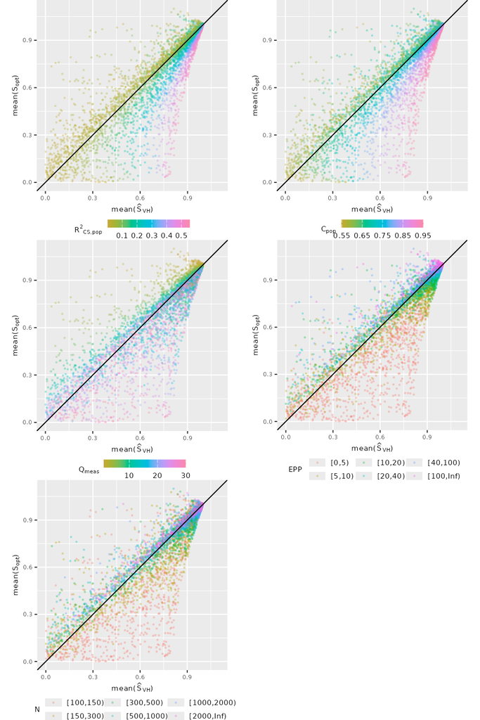

**Figure S28: alternative DGM (see section 4 of manuscript); mean($\hat{S}_{VH}$) plotted against mean($S_{opt}$), non-zero covariance in DGM, presented with respect to apparent model performance**

*Estimator = mean($\hat{S}_{VH}$)*

*Covariance structure = non-zero covariance in DGM*

*By variable = presented with respect to apparent model performance*

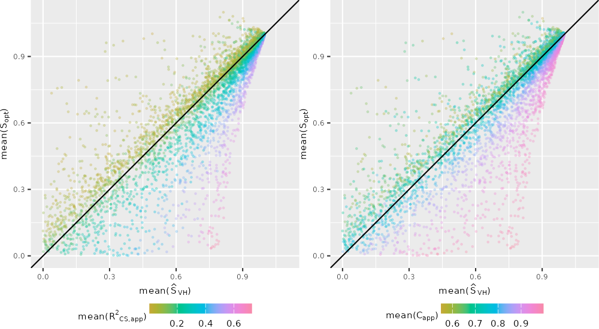

**Figure S29: alternative DGM (see section 4 of manuscript); median($\hat{S}_{VH}$) plotted against median($S_{opt}$), non-zero covariance in DGM, presented with respect to population-level model performance**

*Estimator = median($\hat{S}_{VH}$)*

*Covariance structure = non-zero covariance in DGM*

*By variable = presented with respect to population-level model performance*

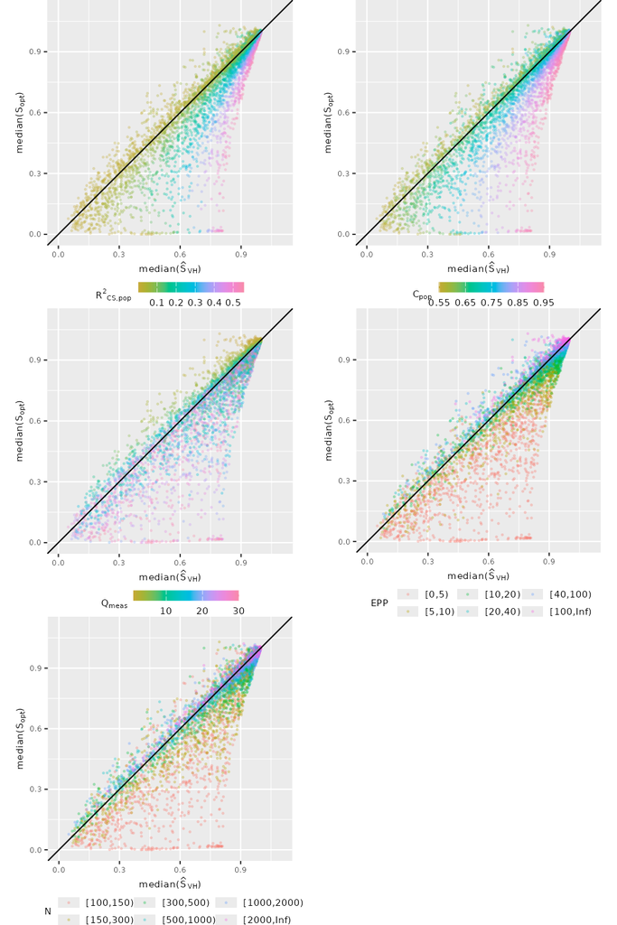

**Figure S30: alternative DGM (see section 4 of manuscript); median($\hat{S}_{VH}$) plotted against median($S_{opt}$), non-zero covariance in DGM, presented with respect to apparent model performance**

*Estimator = median($\hat{S}_{VH}$)*

*Covariance structure = non-zero covariance in DGM*

*By variable = presented with respect to apparent model performance*

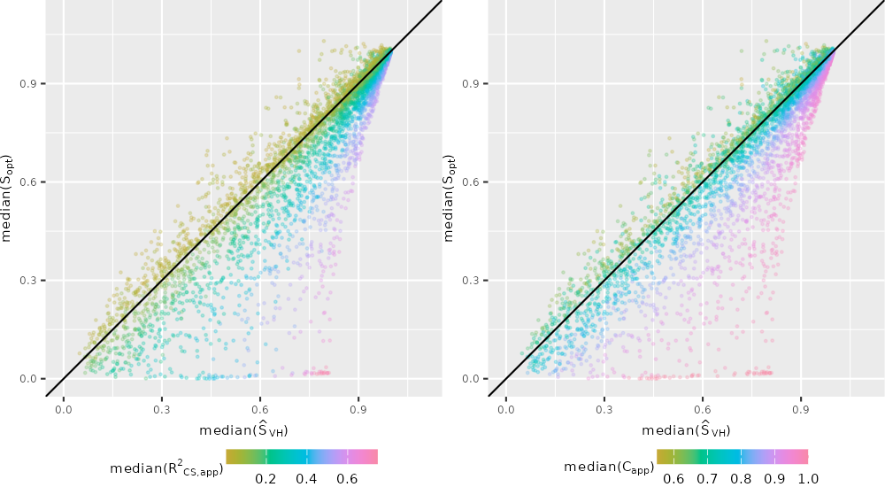

**Figure S31: alternative DGM (see section 4 of manuscript); mean($\hat{S}_{boot}$) plotted against mean($S_{opt}$), non-zero covariance in DGM, presented with respect to population-level model performance**

*Estimator = mean($\hat{S}_{boot}$)*

*Covariance structure = non-zero covariance in DGM*

*By variable = presented with respect to population-level model performance*

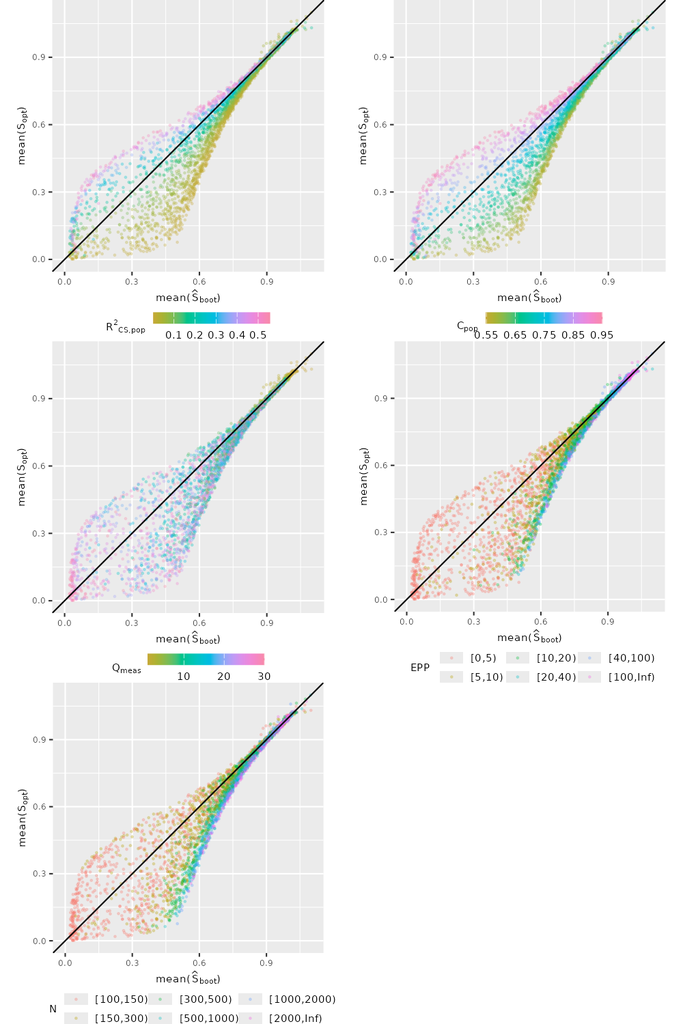

**Figure S32: alternative DGM (see section 4 of manuscript); mean($\hat{S}_{boot}$) plotted against mean($S_{opt}$), non-zero covariance in DGM, presented with respect to apparent model performance**

*Estimator = mean($\hat{S}_{boot}$)*

*Covariance structure = non-zero covariance in DGM*

*By variable = presented with respect to apparent model performance*

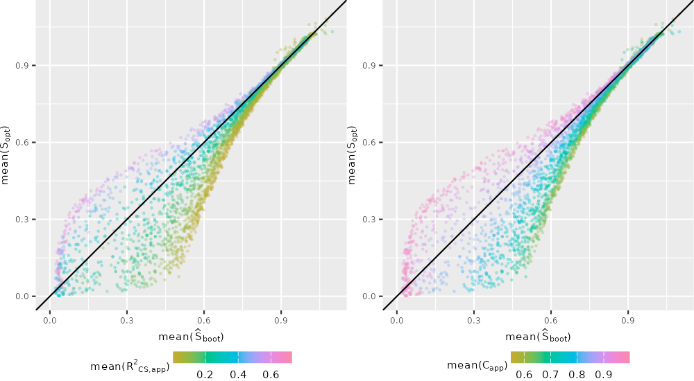

**Figure S33: alternative DGM (see section 4 of manuscript); median($\hat{S}_{boot}$) plotted against median($S_{opt}$), non-zero covariance in DGM, presented with respect to population-level model performance**

*Estimator = median($\hat{S}_{boot}$)*

*Covariance structure = non-zero covariance in DGM*

*By variable = presented with respect to population-level model performance*

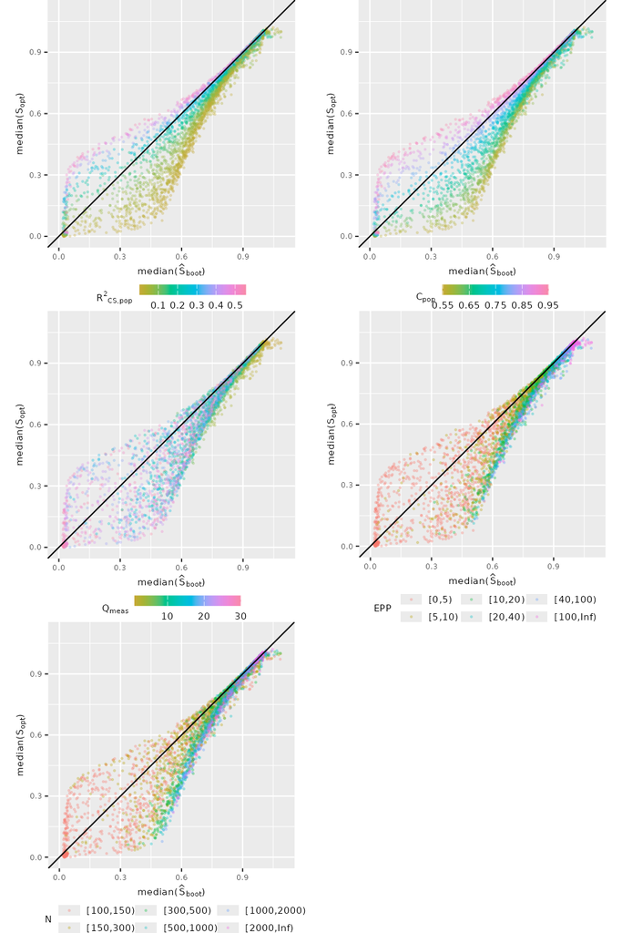

**Figure S34: alternative DGM (see section 4 of manuscript); median($\hat{S}_{boot}$) plotted against median($S_{opt}$), non-zero covariance in DGM, presented with respect to apparent model performance**

*Estimator = median($\hat{S}_{boot}$)*

*Covariance structure = non-zero covariance in DGM*

*By variable = presented with respect to apparent model performance*

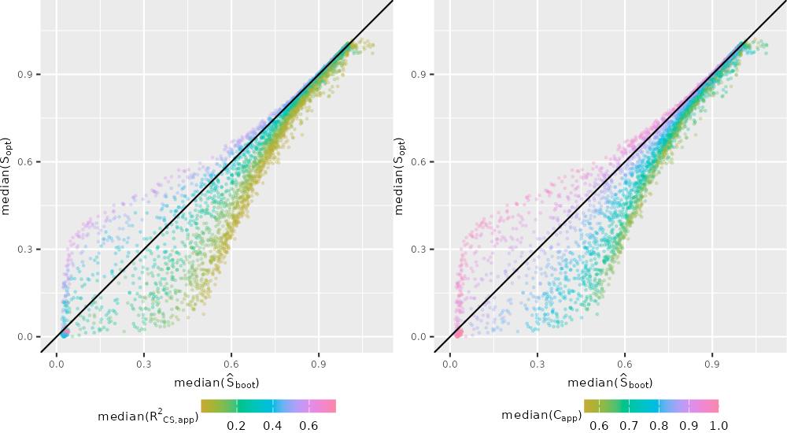

**Figure S35: alternative DGM (see section 4 of manuscript); mean($\hat{S}_{VH}$) plotted against mean($S_{opt}$), zero covariance in DGM, presented with respect to population-level model performance**

*Estimator = mean($\hat{S}_{VH}$)*

*Covariance structure = zero covariance in DGM*

*By variable = presented with respect to population-level model performance*

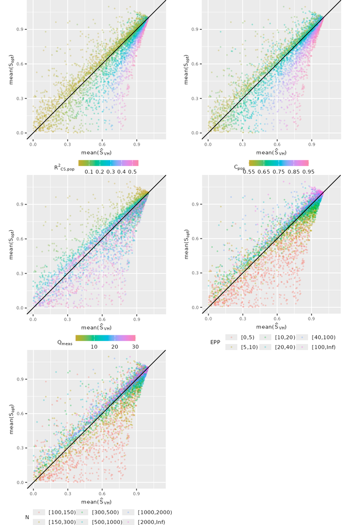

**Figure S36: alternative DGM (see section 4 of manuscript); mean($\hat{S}_{VH}$) plotted against mean($S_{opt}$), zero covariance in DGM, presented with respect to apparent model performance**

*Estimator = mean($\hat{S}_{VH}$)*

*Covariance structure = zero covariance in DGM*

*By variable = presented with respect to apparent model performance*

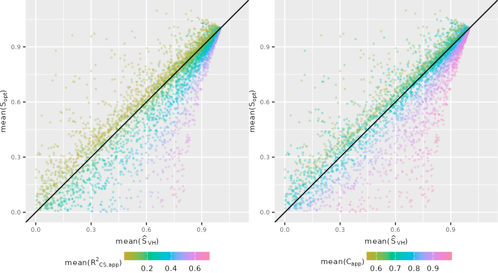

**Figure S37: alternative DGM (see section 4 of manuscript); median($\hat{S}_{VH}$) plotted against median($S_{opt}$), zero covariance in DGM, presented with respect to population-level model performance**

*Estimator = median($\hat{S}_{VH}$)*

*Covariance structure = zero covariance in DGM*

*By variable = presented with respect to population-level model performance*

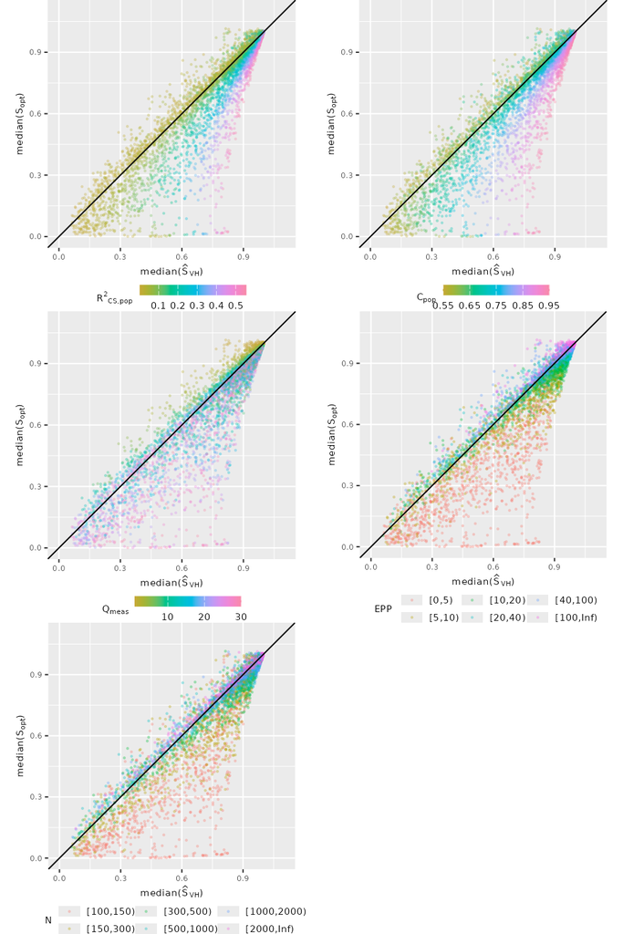

**Figure S38: alternative DGM (see section 4 of manuscript); median($\hat{S}_{VH}$) plotted against median($S_{opt}$), zero covariance in DGM, presented with respect to apparent model performance**

*Estimator = median($\hat{S}_{VH}$)*

*Covariance structure = zero covariance in DGM*

*By variable = presented with respect to apparent model performance*

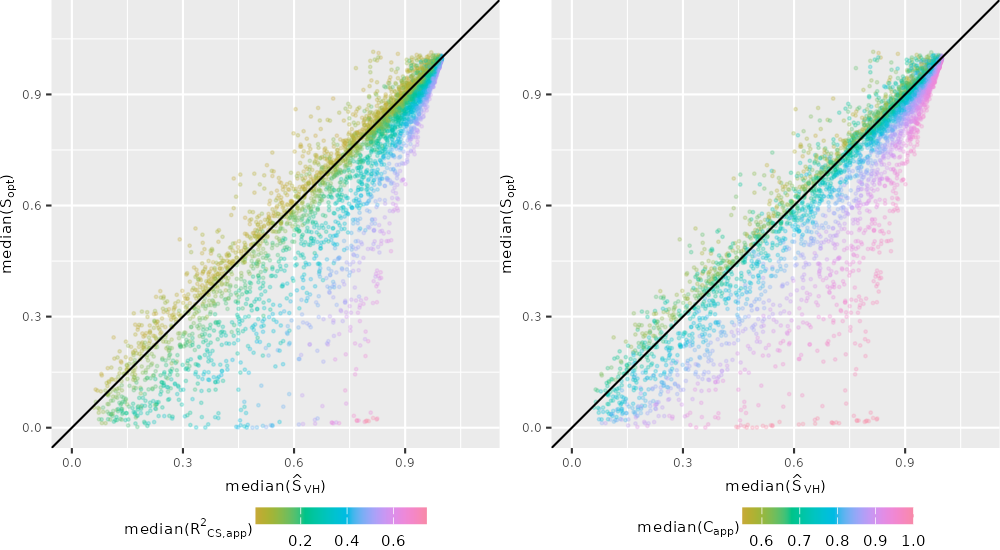

**Figure S39: alternative DGM (see section 4 of manuscript); mean($\hat{S}_{boot}$) plotted against mean($S_{opt}$), zero covariance in DGM, presented with respect to population-level model performance**

*Estimator = mean($\hat{S}_{boot}$)*

*Covariance structure = zero covariance in DGM*

*By variable = presented with respect to population-level model performance*

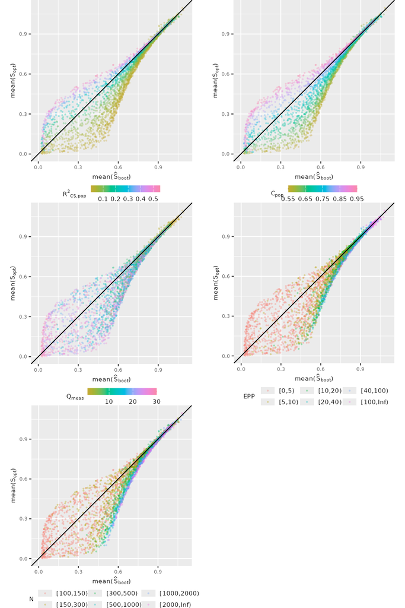

**Figure S40: alternative DGM (see section 4 of manuscript); mean($\hat{S}_{boot}$) plotted against mean($S_{opt}$), zero covariance in DGM, presented with respect to apparent model performance**

*Estimator = mean($\hat{S}_{boot}$)*

*Covariance structure = zero covariance in DGM*

*By variable = presented with respect to apparent model performance*

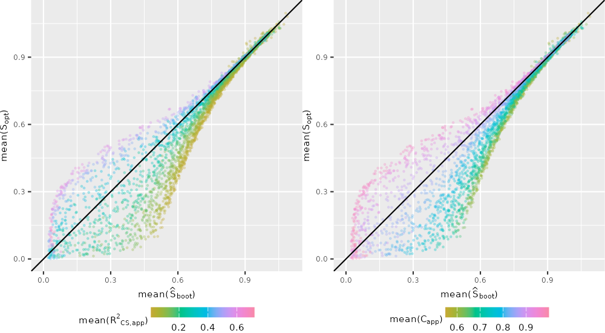

**Figure S41: alternative DGM (see section 4 of manuscript); median($\hat{S}_{boot}$) plotted against median($S_{opt}$), zero covariance in DGM, presented with respect to population-level model performance**

*Estimator = median($\hat{S}_{boot}$)*

*Covariance structure = zero covariance in DGM*

*By variable = presented with respect to population-level model performance*

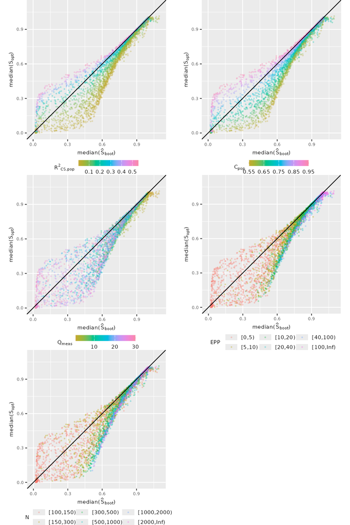

**Figure S42: alternative DGM (see section 4 of manuscript); median($\hat{S}_{boot}$) plotted against median($S_{opt}$), zero covariance in DGM, presented with respect to apparent model performance**

*Estimator = median($\hat{S}_{boot}$)*

*Covariance structure = zero covariance in DGM*

*By variable = presented with respect to apparent model performance*

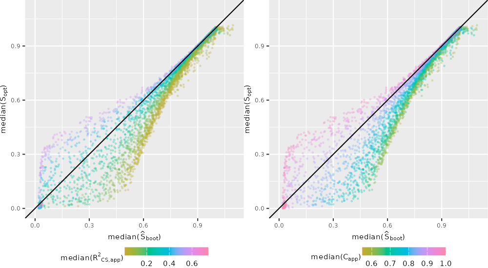

**Figure S43: mean($\hat{S}_{VH}$) plotted against mean($S_{opt}$), grouped by mean($C_{app}$), non-zero covariance in DGM**

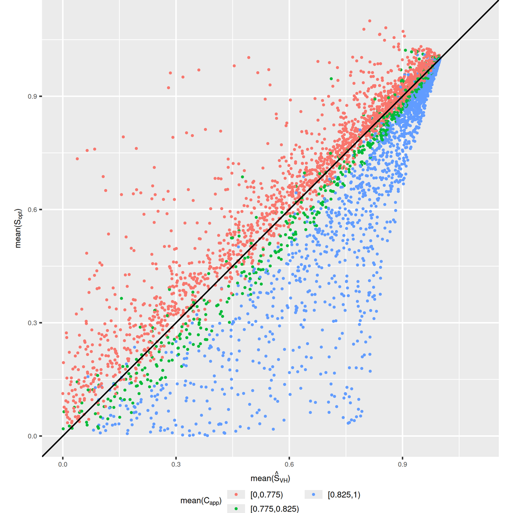

**Figure S44: mean($\hat{S}_{VH}$) plotted against mean($S_{opt}$), grouped by $C_{pop}$, non-zero covariance in DGM**

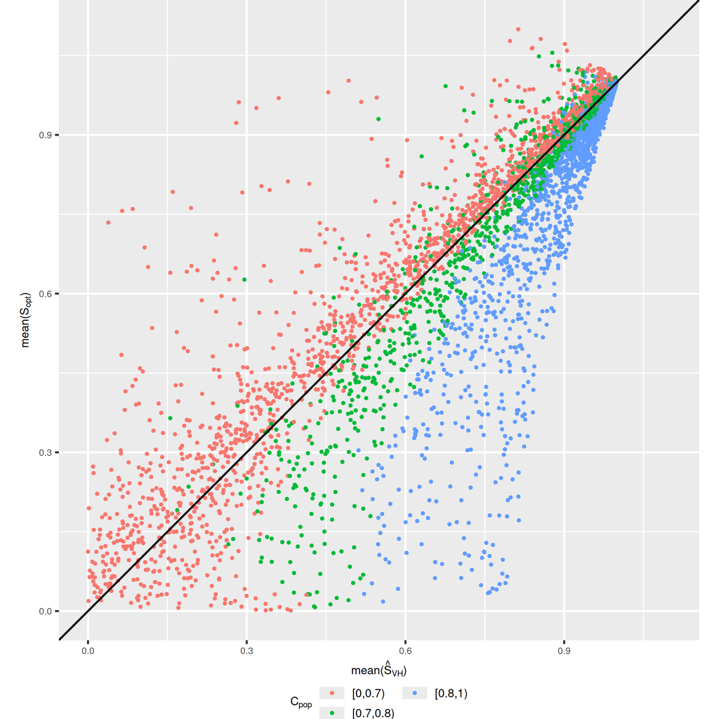

**Figure S45: mean($\hat{S}_VH$) plotted against mean($S_{opt}$), grouped by mean($C_{app}$), zero covariance in DGM**

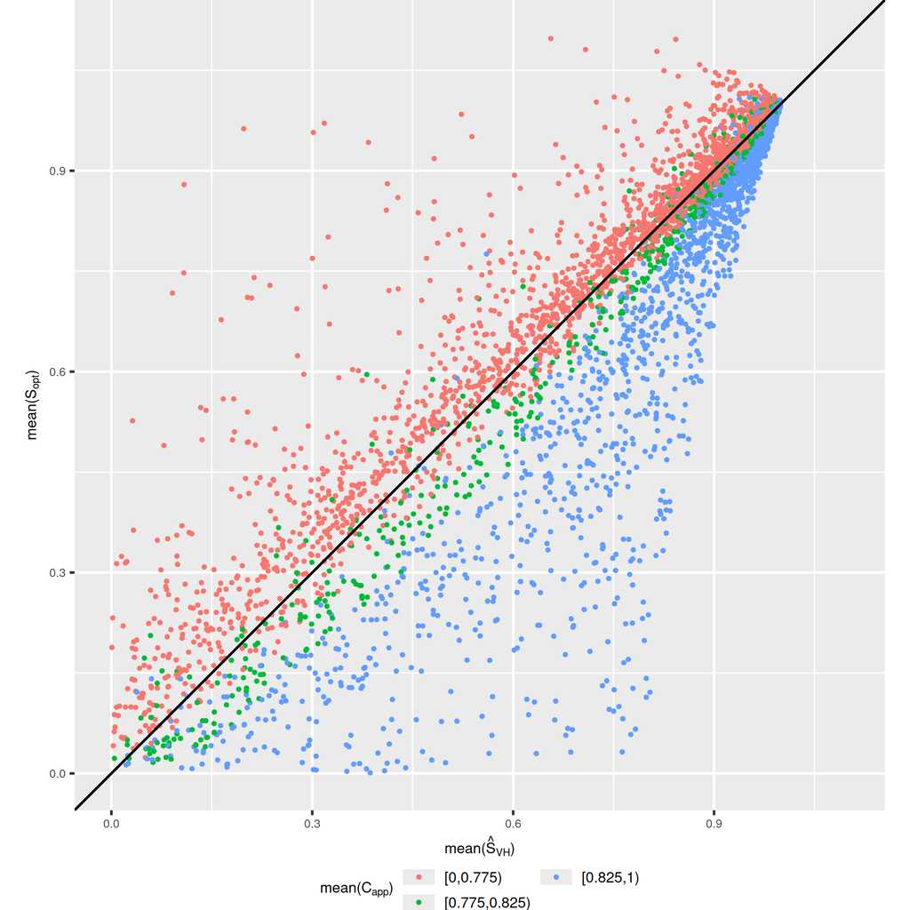

**Figure S46: mean($\hat{S}_{VH}$) plotted against mean($S_{opt}$), grouped by $C_{pop}$, zero covariance in DGM**

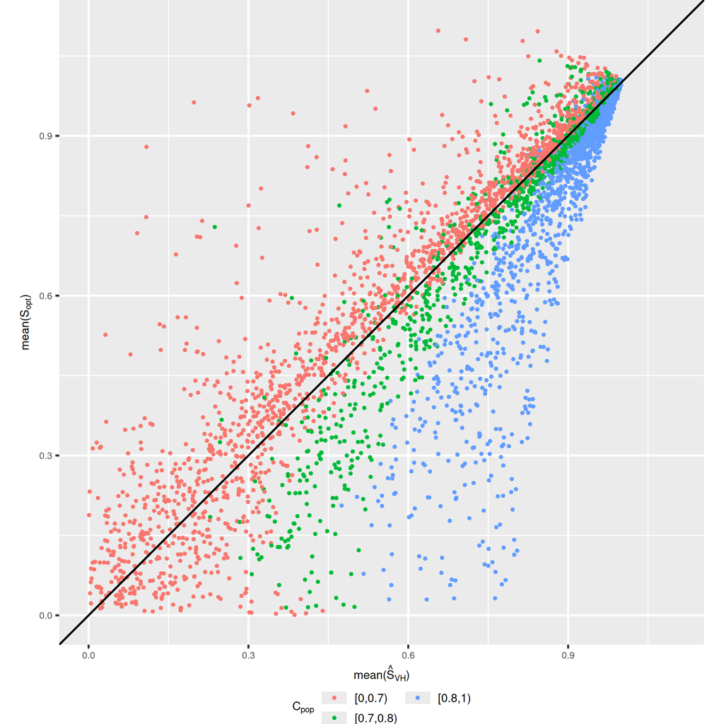

# 2 Simulation study 2

We present a plot of $N_{sim}$ against $N_{original}$:

**Figure S47: $N_{sim}$ plotted against $N_{original}$**

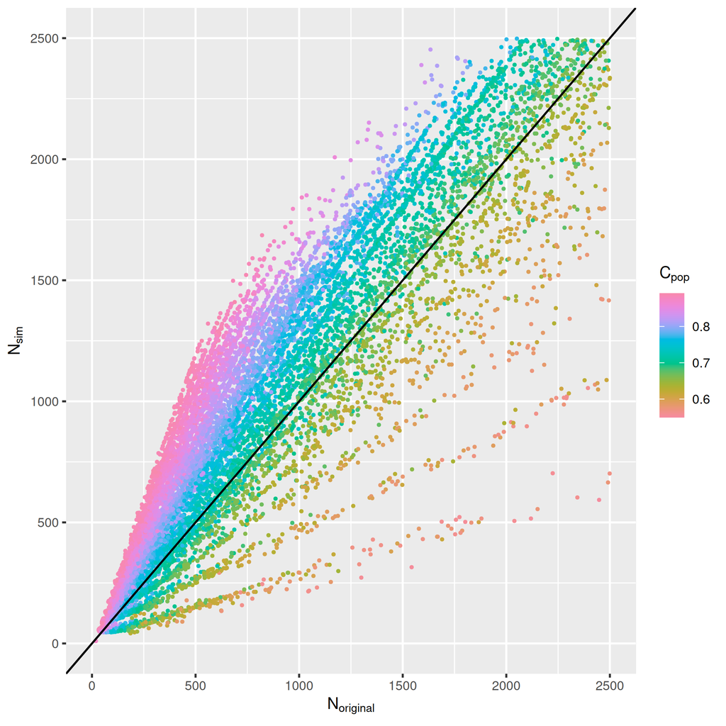